# Seinna R verkefni - Fasteignaverkefni

Kristófer Birgir Hjörleifsson (kbh15)

# Hluti 1 (10 %)

## a) Lesum inn gögnin okkar:

```r
k <- read.table("https://ahj.hi.is/husnaedisverd_2017_21.csv",
                 encoding = "UTF-8", sep = ";", header =T, stringsAsFactors = T)
```

## b) Veljum þrjú hverfi: 280 = Fossvogur, 75 = Skerjafjörður og 180 = Grafarholt

```r
matssvaedi.nota <- c("280", "75", "180")

k <- filter(k, matssvaedi%in%matssvaedi.nota)
```

## c) Kannið gerð breytanna og breytið gerð þeirra sem eru ekki af réttri gerð (ef einhverjar).

```r
# Könnum gerð breyta:
str(k)
```

```
## 'data.frame':    1023 obs. of  5 variables:
##  $ kaupverd  : int  67000 52800 27400 36000 28160 50000 29000 68000 22700 47000 ...
##  $ teg_eign  : Factor w/ 4 levels "Einbýlishús",..: 1 4 2 2 2 4 2 1 2 4 ...
##  $ byggar    : int  1970 1969 2004 1970 1991 1972 2004 1970 2003 2002 ...
##  $ birtm2    : num  197.1 220.7 113.6 127.8 84.8 ...
##  $ matssvaedi: int  280 280 180 280 280 280 180 280 180 180 ...
```

matssvaedi er int en við viljum breyta því í factor breytu.

```r
k <- mutate(k, matssvaedi = factor(matssvaedi))
# Athugum hvort breytingin heppnaðist:
str(k)
```

```
## 'data.frame':    1023 obs. of  5 variables:
##  $ kaupverd  : int  67000 52800 27400 36000 28160 50000 29000 68000 22700 47000 ...
##  $ teg_eign  : Factor w/ 4 levels "Einbýlishús",..: 1 4 2 2 2 4 2 1 2 4 ...
##  $ byggar    : int  1970 1969 2004 1970 1991 1972 2004 1970 2003 2002 ...
##  $ birtm2    : num  197.1 220.7 113.6 127.8 84.8 ...
##  $ matssvaedi: Factor w/ 3 levels "75","180","280": 3 3 2 3 3 3 2 3 2 2 ...
```

## d) Búið til nýja breytu í gagnarammanum ykkar sem inniheldur fermetraverð eignanna, nefnið breytuna fermetraverd.

```r
k$fermetraverd <- k$kaupverd/k$birtm2
```

## e) Búið til nýja breytu sem þið skulið kalla teg_eign_groft sem byggir á teg_eign breytunni. Breytan á að innihalda tvo flokka: Sérbýli (Einbýlishús, Parhús, Raðhús) og Íbúð (Íbúðareign). Ábending: notið fct_recode() aðferðina.

```r
k$teg_eign_groft <- fct_recode(k$teg_eign, "Sérbýli" = "Einbýlishús",
                             "Sérbýli" = "Parhús", "Sérbýli" = "Raðhús",
                             "Íbúð" = "Íbúðareign")
```

## f) Endurnefnið hverfin ykkar með lýsandi nöfnum (ekki kóðanum sem notaður er í gögnunum).

```r
matsv <- fct_recode(k$matssvaedi, "Fossvogurinn" = "280", "Skerjó" = "75",
           "Grafarholtið" = "180")
k$matssvaedi <- matsv
```

## g) Takið slembiúrtak úr gagnasafninu ykkar af stærð 400. Geymið úrtakið ykkar í hlut sem ber heitið urtak.

```r
set.seed(5)
urtak <- sample_n(k, 400)
```

# Hluti 2 (25 %)

## h) Búið til töflu sem sýnir fjölda eigna í hverfunum þremur eftir gerð eigna (sérbýli eða íbúðir).

```r
tab1 <- table(urtak$teg_eign_groft, urtak$matssvaedi)
kable(tab1, align = "c") %>%
  kable_styling(bootstrap_options = c("striped", "hover"),
                full_width = F,
                font_size = 14,
                position = "left")
```

|  | Skerjó | Grafarholtið | Fossvogurinn |
| --- | --- | --- | --- |
| Sérbýli | 19 | 26 | 58 |
| Íbúð | 19 | 181 | 97 |

## i) Búið til töflu sem sýnir hlutfall sérbýla og íbúða í hverfunum þremur. Það á s.s. að vera hægt að lesa hvert hlutfall sérbýla og íbúða er í hverju hverfi fyrir sig.

```r
tab2 <- prop.table(table(urtak$teg_eign_groft, urtak$matssvaedi), margin = 2)
kable(tab2, digits = 3, align = "c", ) %>%
  kable_styling(bootstrap_options = c("striped", "hover"),
                full_width = F,
                font_size = 14,
                position = "left")
```

|  | Skerjó | Grafarholtið | Fossvogurinn |
| --- | --- | --- | --- |
| Sérbýli | 0.5 | 0.126 | 0.374 |
| Íbúð | 0.5 | 0.874 | 0.626 |

## j) Kannið með viðeigandi tilgátuprófi hvort samband sé á milli hverfa og gerð eigna (sérbýli og íbúða). Sýnið úttakið úr prófinu. Eru forsendur til að nota prófið uppfylltar? Setjið tilgáturnar fram, tilgreinið gildið á prófstærðinni, p-gildið og hvaða ályktun þið dragið.

Notum kí-kvaðratpróf þar sem við erum að athuga hvort samband sé á milli hlutfalla þriggja þýða.

```r
chi_j <- chisq.test(table(urtak$teg_eign_groft, urtak$matssvaedi))
chi_j
```

```
##
##  Pearson's Chi-squared test
##
## data:  table(urtak$teg_eign_groft, urtak$matssvaedi)
## X-squared = 41.562, df = 2, p-value = 0.0000000009438
```

Gefum okkur villulíkur $\alpha$ = 0.05.

Tilgáturnar eru
$$H_0: p_1 = p_2 = p_3 \\
H_1: \text{hlutföllin eru ekki öll jöfn}$$

Prófstærðin okkar er 41.5621655 og p-gildið er 0. Þar sem p-gildið er minna en $\alpha$ þá höfnum við núlltilgátunni.

Athugum núna hvort að forsendurnar fyrir því að nota þetta tilgátupróf hafi verið til staðar.

```r
chi_j$expected
```

```
##
##           Skerjó Grafarholtið Fossvogurinn
##   Sérbýli  9.785      53.3025      39.9125
##   Íbúð    28.215     153.6975     115.0875
```

Í töflunni hér að ofan fyrir væntanlega tíðni eru allar tölurnar stærri en 5 og því er í lagi að nota prófið.

# Hluti 3 (25 %)

## k) Kannið með viðeigandi tilgátuprófi hvort munur sé á meðfermetraverði fasteigna eftir því hvort þær séu sérbýli eða íbúðir. Setjið tilgáturnar fram, tilgreinið gildið á prófstærðinni, p-gildið og hvaða ályktun þið dragið.

Notum tvíhliða t-próf af því að við erum að athuga mun á meðaltali tveggja stórra þýða.

```r
t_test1 <- t.test(urtak$fermetraverd ~ urtak$teg_eign_groft)
t_test1
```

```
##
##  Welch Two Sample t-test
##
## data:  urtak$fermetraverd by urtak$teg_eign_groft
## t = 0.70759, df = 174.68, p-value = 0.4801
## alternative hypothesis: true difference in means between group Sérbýli and group Íbúð is not equal to 0
## 95 percent confidence interval:
##  -7.989438 16.920049
## sample estimates:
## mean in group Sérbýli    mean in group Íbúð
##              291.4421              286.9768
```

Tilgáturnar eru:
$$H_0: \mu_1 - \mu_2 = \delta \\
H_1: \mu_1 - \mu_2 \ne \delta$$
Gildið á prófstærðinni er: 0.708 og p-gildið er 0.48. Þar sem p-gildið er stærra en $\alpha$ þá getum við ekki hafnað $H_0$ og drögum því enga ályktun.

## l) Búið til nýja breytu, staerd01, sem gefur til kynna hvort eignir séu stærri eða minni en 150 fermetrar (það skiptir ekki máli í hvorum flokknum 150 fermetra eignir lenda). Kallið flokkinn með stærri eignunum Stærri og minni eignunum Minni. Ábending: notið ifelse() til að búa til breytuna.

```r
urtak$staerd01 <- ifelse(urtak$birtm2 > 150, "Stærri", "Minni")
```

## m) Kannið með viðeigandi tilgátuprófi hvort munur sé á meðfermetraverði fasteigna eftir því hvort þær séu stærri eða minni en 150 fermetrar. Setjið tilgáturnar fram, tilgreinið gildið á prófstærðinni, p-gildið og hvaða ályktun þið dragið.

Athugum fyrst með viðeigandi prófi hvort dreifnin á meðalfermetraverðinu sé svipuð á milli flokkana

```r
lm <- var.test(urtak$fermetraverd ~ urtak$staerd01)
lm
```

```
##
##  F test to compare two variances
##
## data:  urtak$fermetraverd by urtak$staerd01
## F = 1.4076, num df = 283, denom df = 115, p-value = 0.03521
## alternative hypothesis: true ratio of variances is not equal to 1
## 95 percent confidence interval:
##  1.024348 1.895572
## sample estimates:
## ratio of variances
##           1.407619
```

Miðað við að p-gildið úr fyrrgreindu prófi er 0.0352104 sem er minna en $\alpha$ = 0.05 að þá getum við ályktað að dreifnin sé ólík.

Þá framkvæmum við tvíhliða t-próf til að athuga hvort munur sé á meðalfermetraverði fasteigna eftir því hvort þær séu stærri eða minni en 150 fermetrar.

```r
t_test2 <- t.test(urtak$fermetraverd ~ urtak$staerd01)
t_test2
```

```
##
##  Welch Two Sample t-test
##
## data:  urtak$fermetraverd by urtak$staerd01
## t = 1.2184, df = 251.47, p-value = 0.2242
## alternative hypothesis: true difference in means between group Minni and group Stærri is not equal to 0
## 95 percent confidence interval:
##  -4.207916 17.861485
## sample estimates:
##  mean in group Minni mean in group Stærri
##             290.1064             283.2796
```

Tilgáturnar eru:
$$H_0: \mu_1 - \mu_2 = \delta \\
H_1: \mu_1 - \mu_2 \ne \delta$$
Gildið á prófstærðinni er: 1.218 og p-gildið er 0.2242042. Þar sem p-gildið er stærra en $\alpha$ þá getum við ekki hafnað $H_0$ og drögum því ekki ályktun að það sé munur á fermetraverði íbúða eftir því hvort þær séu stærri eða minni en 150 fermetrar.

# Hluti 4 (30%)

## n) Teiknið viðeigandi mynd af breytunum fermetraverd og matssvaedi.

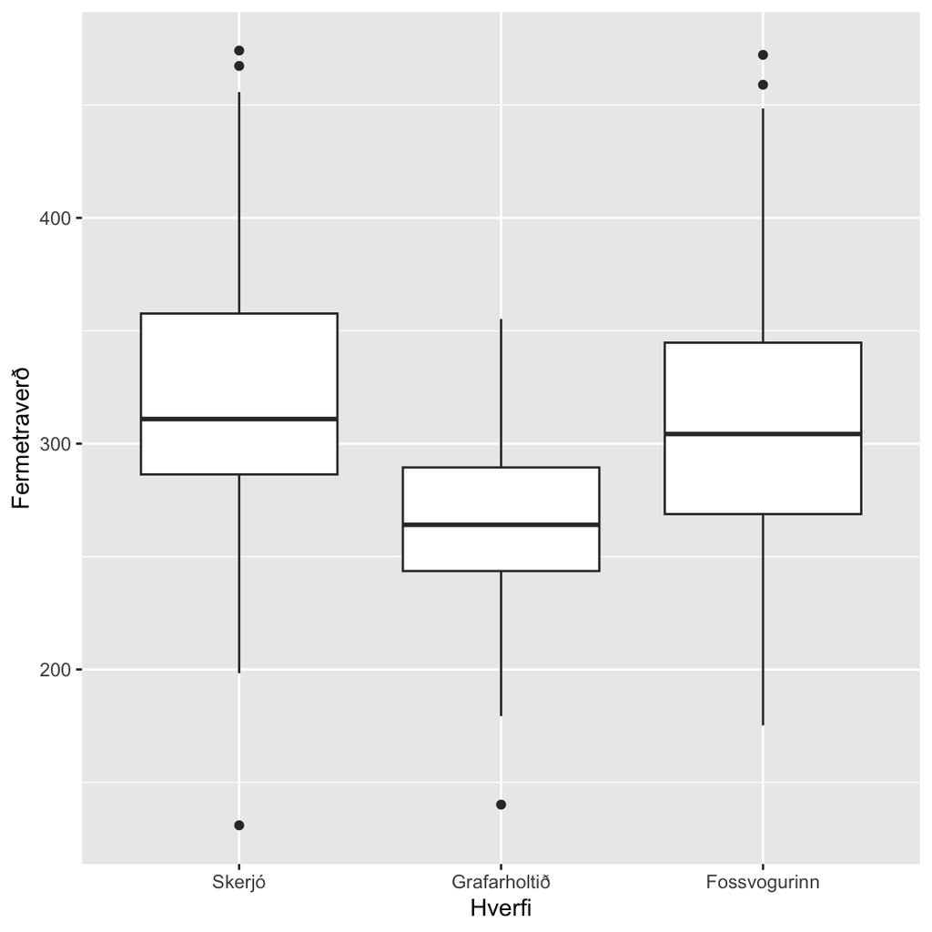

```r
ggplot(urtak, aes(x = matssvaedi, y = fermetraverd)) + geom_boxplot() + xlab('Hverfi') + ylab('Fermetraverð')
```

## o) Kannið með viðeigandi tilgátuprófi hvort munur sé á meðalfermetraverði fasteigna í hverfunum þremur. Sýnið úttakið úr prófinu. Setjið tilgáturnar fram, tilgreinið gildið á prófstærðinni, p-gildið og hvaða ályktun þið dragið. Segði nokkur orð um hvort forsendur tilgátuprófsins séu uppfylltar. Þið þurfið ekki að prófa það með tilgátuprófi, nóg er að notast við myndrit (t.d. myndina í lið n).

Til að athuga hvort munur sé á meðaltali fleiri en tveggja hópa er nauðsynlegt að nota fervikagreiningu. Á myndinni sem við teiknuðum í lið n) er hægt að sjá að dreifnin á fermetraverðinu er nokkuð svipuð á milli hverfa og því eru forsendurnar fyrir því að nota fervikagreiningu uppfylltar.

```r
fervik <- aov(fermetraverd ~ matssvaedi, data = urtak)
a_fervik <- anova(fervik)
a_fervik
```

```
## Analysis of Variance Table
##
## Response: fermetraverd
##             Df Sum Sq Mean Sq F value                Pr(>F)
## matssvaedi   2 227705  113852   46.93 < 0.00000000000000022 ***
## Residuals  397 963122    2426
## ---
## Signif. codes:  0 '***' 0.001 '**' 0.01 '*' 0.05 '.' 0.1 ' ' 1
```

Tilgáturnar eru:
$$H_0: \mu_1 = \mu_2 = \mu_3 \\
H_1: \text{A.m.k eitt meðaltal er frábrugðið hinum}$$
Gildið á prófstærðinni er 46.93 og p-gildið er 0. Fyrst að prófstærðin er greinilega stærri en p-gildið að þá höfnum við $H_0$ og ályktum að a.m.k eitt meðaltal sé frábrugðið hinum.

## p) Teiknið viðeigandi mynd af breytunum birtm2 og kaupverd. Segið með nokkrum orðum hvort þið teljið viðeigandi að nota einfalt línulegt aðhvarf til að lýsa sambandinu á milli breytanna.

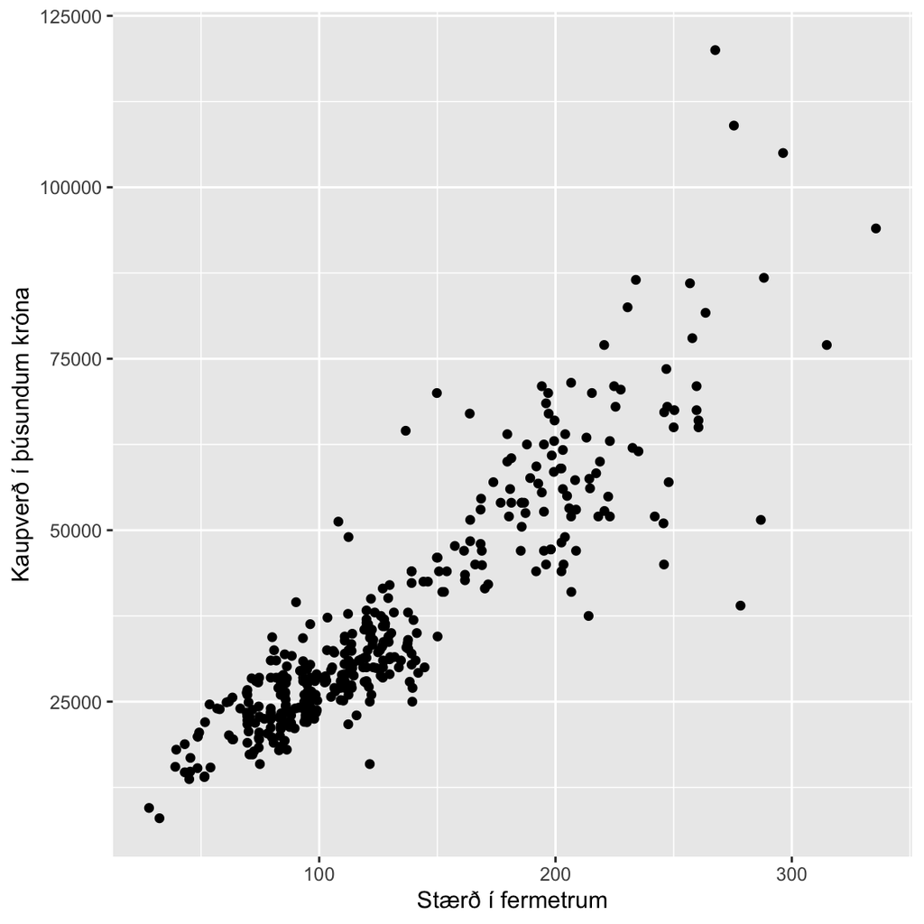

```r
ggplot(urtak, aes(x = birtm2,y = kaupverd)) + geom_point() + xlab("Stærð í fermetrum") + ylab("Kaupverð í þúsundum króna")
```

Athugum hvort að forsendur aðhvarfsgreiningar séu til staðar með því að nota leifarit

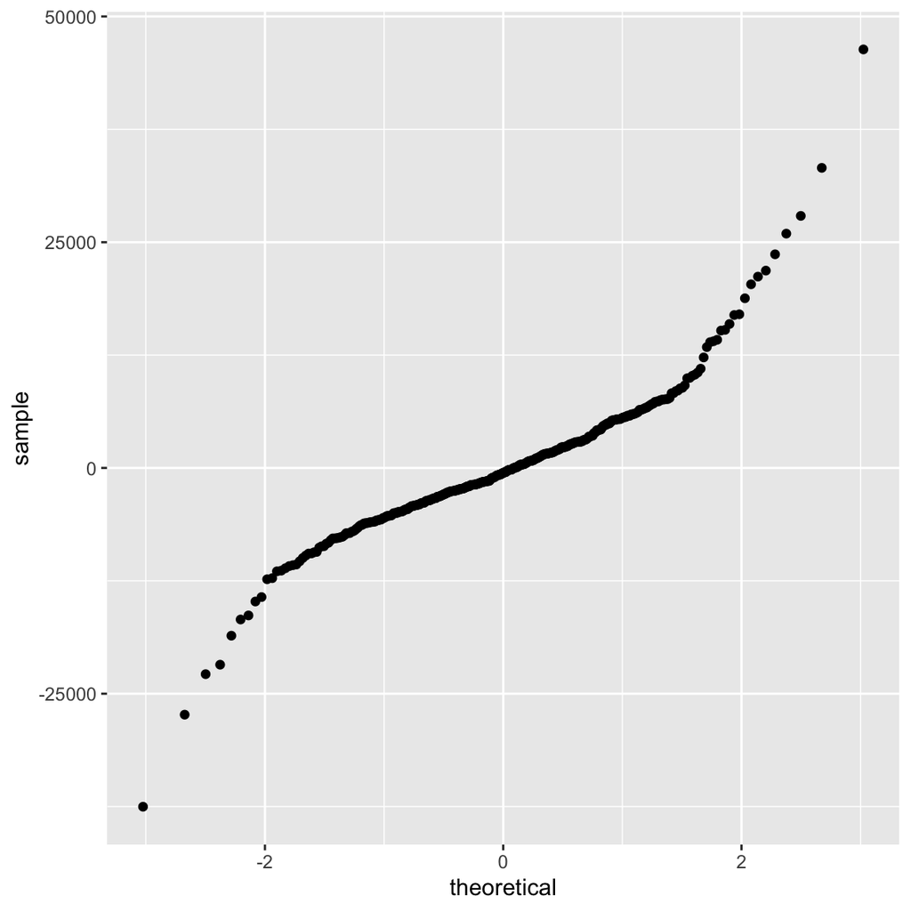

```r
p <- lm(kaupverd ~ birtm2, data = urtak)
ggplot(data = p, aes(sample = .resid)) + stat_qq()
```

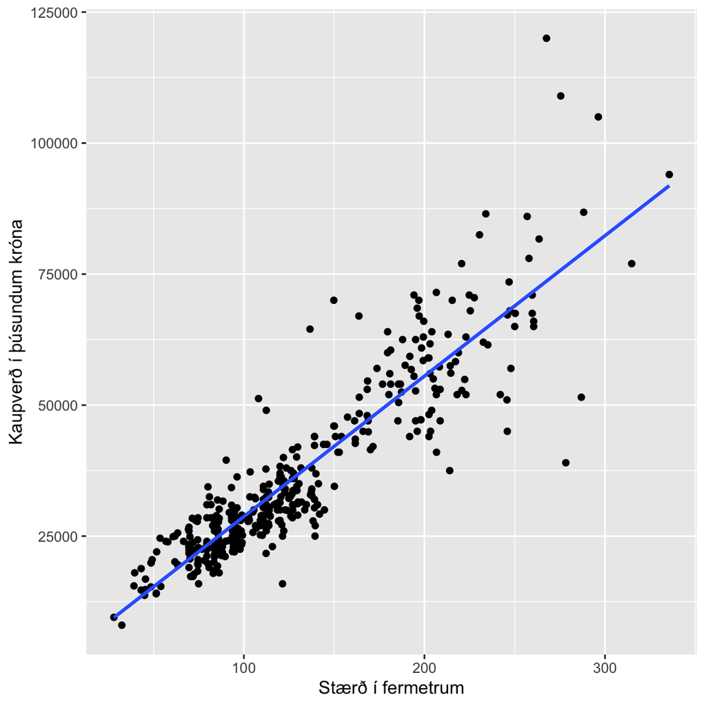

```r
ggplot(urtak, aes(x = birtm2,y = kaupverd)) + geom_point() + xlab("Stærð í fermetrum") + ylab("Kaupverð í þúsundum króna") + geom_smooth(method='lm', se = F)
```

## q) Smíðið einfalt aðhvarfslíkan sem lýsir sambandi stærðar og kaupverðs eigna. Með líkaninu á að vera hægt að spá fyrir um kaupverð úr frá stærð. Tilgreinið í texta hvert matið á skurðpunktinum og hallatölunni eru ásamt skýringarhlutfallinu (notið klumpakommur). Segið í örfáum orðum hvað hallatalan segir okkur í þessu tilviki.

```r
q <- lm(kaupverd ~ birtm2, data = urtak)
q
```

```
##
## Call:
## lm(formula = kaupverd ~ birtm2, data = urtak)
##
## Coefficients:
## (Intercept)       birtm2
##      1947.2        267.9
```

```r
skurdp <- q$coefficients[1]
hallat <- q$coefficients[2]
qsum <- summary(q)
qsum
```

```
##
## Call:
## lm(formula = kaupverd ~ birtm2, data = urtak)
##
## Residuals:
##    Min     1Q Median     3Q    Max
## -37517  -3865   -554   3077  46350
##
## Coefficients:
##             Estimate Std. Error t value            Pr(>|t|)
## (Intercept) 1947.184    918.467    2.12              0.0346 *
## birtm2       267.949      6.444   41.58 <0.0000000000000002 ***
## ---
## Signif. codes:  0 '***' 0.001 '**' 0.01 '*' 0.05 '.' 0.1 ' ' 1
##
## Residual standard error: 7458 on 398 degrees of freedom
## Multiple R-squared:  0.8129, Adjusted R-squared:  0.8124
## F-statistic:  1729 on 1 and 398 DF,  p-value: < 0.00000000000000022
```

Mat á skurðpunkti er 1947.2 og mat á hallatölu er 267.95. Skýringarhlutfallið er 0.8129. Miðað við að hallatalan er jákvæð getum við dregið þá ályktun að því stærri sem fasteignin er, því hærra verður kaupverðið.

Nánar tiltekið: þegar stærð íbúðar hækkar um 1 fm að þá má álykta að kaupverðið muni hækka um sirka 268 þúsund krónur.